# Homework 3

Alejandro Rosales

September 30, 2019

**PROBLEM 1**:

# Study

Peanuts from the same processing batch were divided into 27 equal samples by weight and the samples were randomly assigned to one of the three oven types and solution types and subjected to the standard white-roast procedure. All were then processed by the same mechanical skinner and the yield (percent of whole, skinned peanuts) was recorded. The data are in the file peanutStudy.csvPreview the document. Due to the cost of replacing standard ovens with conventional or microwave ovens, and likewise using sodium chloride or potassium chloride compared to water, the researcher insist all hypothesis testing be performed at the 0.1% significance level (hint: If you build any confidence intervals you can specify the confidence level with level = 0.999).

# Data input and wrangling

```r
peanutStudy <- read.csv("peanutStudy.csv")
head(peanutStudy)
```

```
##         Oven           Solution Yield
## 1 Convection Potassium chloride  64.3
## 2 Convection Potassium chloride  70.0
## 3 Convection Potassium chloride  67.6
## 4 Convection    Sodium chloride  81.4
## 5 Convection    Sodium chloride  77.9
## 6 Convection    Sodium chloride  83.3
```

# Exploratory Data Analysis

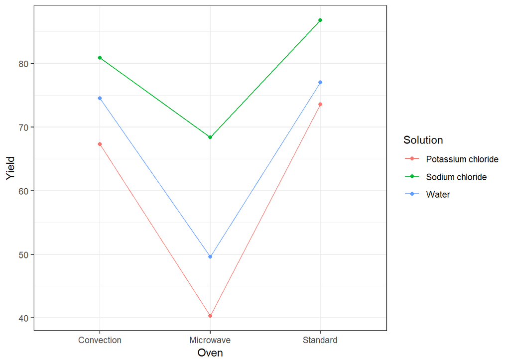

```r
ggplot(peanutStudy, aes(x=Oven,y=Yield, color=Solution, group=Solution))  +
  stat_summary(fun.y=mean, geom="point") +
  stat_summary(fun.y=mean, geom="line") +
  theme_bw()
```

```r
peanutStudy.anova <- aov(Yield ~ Oven + Solution + Oven:Solution, data=peanutStudy)
summary(peanutStudy.anova)
```

```
##               Df Sum Sq Mean Sq F value   Pr(>F)
## Oven           2   3532  1765.8 109.688 8.29e-11 ***
## Solution       2   1544   771.8  47.945 6.15e-08 ***
## Oven:Solution  4    244    60.9   3.786    0.021 *
## Residuals     18    290    16.1
## ---
## Signif. codes:  0 '***' 0.001 '**' 0.01 '*' 0.05 '.' 0.1 ' ' 1
```

Since the p-values for Oven is 8.29e-11 and the p-value for Soultions is 6.15e-08, which are both less than alpha which is .001 we are able to tell that both oven and soultion impacts the yields.

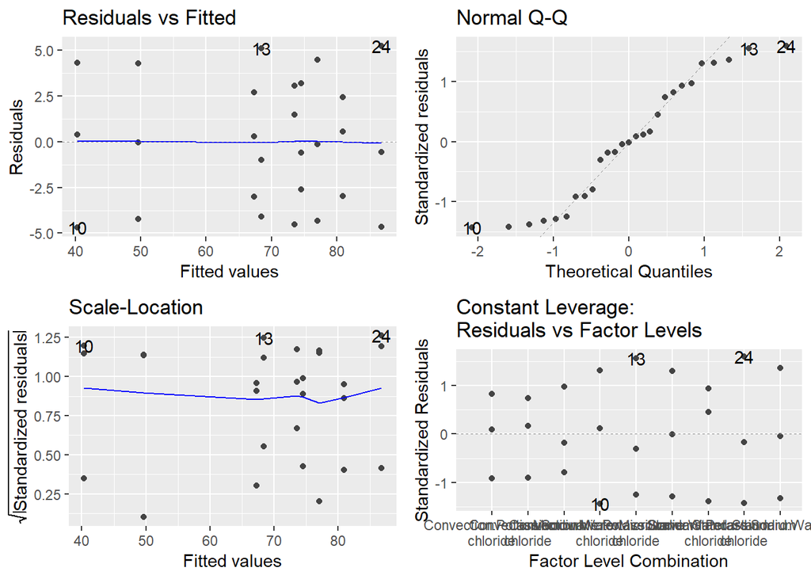

```r
autoplot(peanutStudy.anova)
```

There does not appear to be a pattern in the residual graph which tells us that there is equal error variance. Thhe data points on the QQ-plot appear to follow a stroaight diagnoal line whcih tells us there is normality. The porblem tells us that they data is randomly distributed.

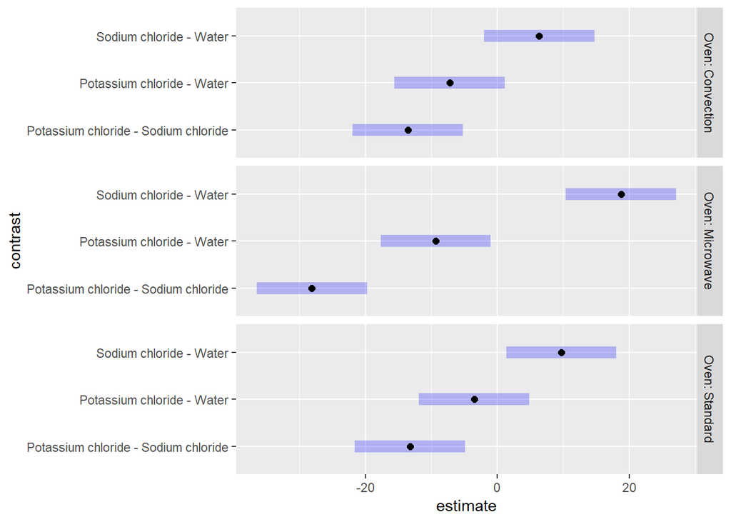

```r
peanutStudy.mc <- emmeans(peanutStudy.anova, pairwise ~ Solution | Oven)
plot(peanutStudy.mc$contrast)
```

**PROBLEM 2**:

Acid rain is considered by some environmentalist to be the nation’s most serious environmental problem. It is formed by the combination of water vapor in clouds with nitrogen oxide and sulfuric dioxide emissions from the burning of coal, oil and natural gas. The acidity of rain in central and northern Florida consistently ranges from 4.5 to 5 on the pH scale, a decidedly acid condition. To determine the effects of acid rain on the acidity of soils in a natural ecosystem, engineers at the University of Florida’s Institute of Food and Agricultural Sciences irrigated experimental plots near Gainesville, Florida, with acid rain at two pH levels, 3.7 and 4.5. The acidity of the soil was then measured at three different depths, 0-15, 15-30, and 30-45 centimeters. Tests were conducted at three time periods which can be considered homogeneous experimental conditions. (Note that: different tests were done on different soil samples.) The data are available acidRainStudy.csv Preview the document. Determine the effects of acid rain levels and depth on the acidity of soil.

# Data input and wrangling

```r
acidRainStudy <- read.csv("acidRainStudy.csv")
head(acidRainStudy)
```

```
##   TimePeriod Rain.pH   Depth Soil.pH
## 1       Apr3     3.7  0-15cm    5.33
## 2       Apr3     3.7 15-30cm    5.27
## 3       Apr3     3.7 30-45cm    5.37
## 4       Apr3     4.5  0-15cm    5.33
## 5       Apr3     4.5 15-30cm    5.03
## 6       Apr3     4.5 30-45cm    5.40
```

```r
acidRainStudy <- acidRainStudy %>%
  mutate(`Rain.pH` = as.factor(`Rain.pH`),
         Depth = as.factor(Depth))
```

# EDA

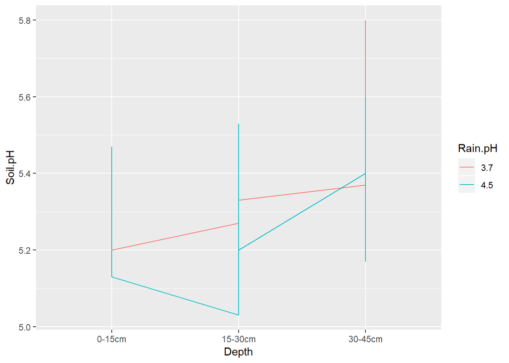

```r
ggplot(acidRainStudy) +
  geom_line(aes(x=Depth, y=`Soil.pH`, color=Rain.pH, group=Rain.pH))
```

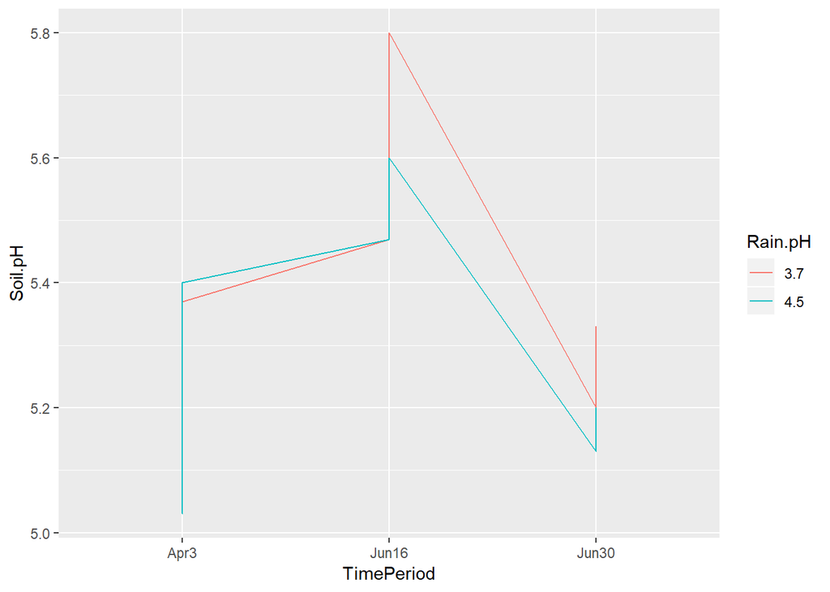

```r
ggplot(acidRainStudy) +
  geom_line(aes(x=TimePeriod, y=`Soil.pH`, color=Rain.pH, group=Rain.pH))
```

```r
acidRainStudy.anova <- aov(Soil.pH ~ TimePeriod*Rain.pH*Depth + Error(Rain.pH/TimePeriod), data=acidRainStudy)
summary(acidRainStudy.anova)
```

```
##
## Error: Rain.pH
##         Df  Sum Sq Mean Sq
## Rain.pH  1 0.03042 0.03042
##
## Error: Rain.pH:TimePeriod
##                    Df Sum Sq Mean Sq
## TimePeriod          2 0.3815 0.19074
## TimePeriod:Rain.pH  2 0.0033 0.00167
##
## Error: Within
##                          Df  Sum Sq Mean Sq
## Depth                     2 0.06714 0.03357
## TimePeriod:Depth          4 0.06436 0.01609
## Rain.pH:Depth             2 0.00781 0.00391
## TimePeriod:Rain.pH:Depth  4 0.03182 0.00796
```

#Assumptions

[figure not shown]

```r
autoplot(peanutStudy.anova)
```

# Multiple Comparison Follow ups

```r
# acidRainStudy.mc <- emmeans(acidRainStudy.anova, Rain.pH, Soil.pH)
# contrast(acidRainStudy.mc, "trt.vs.ctrl", ref=1)

# acidRainStudy.mc2 <- emmeans(acidRainStudy.anova, Soil.pH, Rain.pH)
# contrast(acidRainStudy.mc2, "trt.vs.ctrl", ref=1)
```

**PROBLEM 3**:

A state highway department studied the wear characteristics of four different paint formulations at five locations in the state. The standard, currently used paint (paint 1) and three experimental paints (paints 2, 3, 4) were included in the study. The five locations were randomly selected, thus reflecting variations in traffic densities throughout the state. At each location, the four different paints were applied to the chosen road surface in randomly selected places in close proximity. After a suitable period of exposure to weather and traffic, a combined measure of paint durability and visibility was obtained.

What kind of designed experiment is used here? (Choose from: one-way design, one-way with blocks design, two-way design, two-way with blocks design, repeated measures design)

**Two way anova**

What is the response variable in the study?

**Durability and Visibilty**

List all the different treatments in the study.

**Randomly selected locations, randomly selected road surface, weather and traffic**

If doing a multiple comparison procedure on the factor of interest in this study, which technique would be the most appropriate: Bonferroni, Tukey, or Dunnett? Justify in one sentence.

Dunett because we are doing a Two way Anova.

**PROBLEM 4**:

Two experimental pain killer drugs for relief of migraine headaches were studied at a major medical center. Ten persistent migraine sufferers were randomly selected for a pilot study and received (in random order) each of the four treatment combinations, with a suitable interval between drug administrations. The decrease in pain intensity was used as the response variable. The four treatments used in the study were as follows: A1B1 = low dose of both drugs; A1B2 = low dose of drug A, high dose of drug B; A2B1 = high dose of drug A, low dose of drug B; A2B2 = high dose of both drugs.

What kind of designed experiment is used here? (Choose from: one-way design, one-way with blocks design, two-way design, two-way with blocks design, repeated measures design)

**Two way blocked anova**

What is/are the factor/factors in this study?

**The factors are the doses of both drugs**

What are the levels of the factor (or factors) you cited in part 2?

**Low or high does of drug A in combination with low or high dose of drug B**

For any factor/factors you cited in part 2, indicate if they are within-subjects factors or between-subjects factors.

**Between conditions because two or more subject groups experience their own unique condition.**

What is the purpose of randomizing the order of the treatments here?

** It is to remove bias when testing**